# 01-roulette-simulation

Weixi Chen

09 15, 2021

# 1 Introduction

Today, we’re going to share some information about a traditional game of chance, Roulette. We also imagine a gambler using the “Martingale” strategy to play this game, and simulate the gambler’s earnings(or losses).

## 1.1 Roulette game and its rules

A roulette table composed of 38 (or 37) evenly sized pockets on a wheel. The pockets are colored red, black, or green. The pockets are also numbered. Roulette is a game of chance in which a pocket is randomly selected. Gamblers may wager on several aspects of the outcome. For example, one may place a wager that the randomly selected pocket will be red or odd numbered or will be a specific number.

For this blog, we used the roulette with 38 pockets of which 2 are green, 18 are red, and 18 are black. The payout for a bet on black (or red) is $1 for each $1 wagered. This means that if a gambler bets $1 on black and the randomly selected pocket is black, then the gambler will get the original $1 wager and an additional $1 as winnings.

Here is an example of the roulette we used:

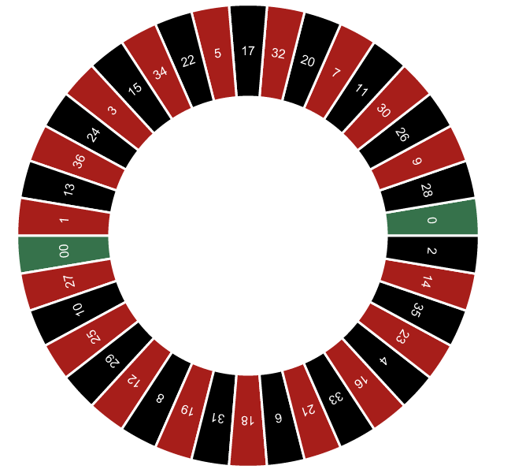

Roulette we used

## 1.2 the “Martingale” strategy

The “Martingale” strategy is a classic roulette strategy, which had the gambler double the bet after every loss, so that the first win would recover all previous losses plus win a profit equal to the original stake. Here is a simplified steps for the “Martingale” strategy:

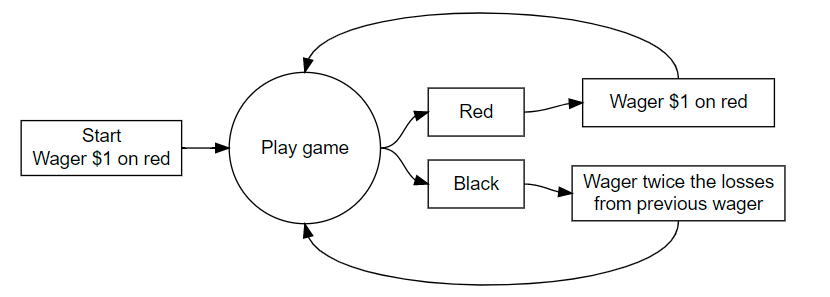

the “Martingale” strategy

Now, we are going to do some simulations for an imagined gambler playing the roulette game with the “Martingale” strategy.

# 2 Simulations

## 2.1 Clarifications of the parameters

First, we need to define some parameters to make the problem more clear.

| Parameter | starting value |
| --- | --- |
| starting_budget | $200 |
| winning_threshold | $300 (starting_budget + $100 winnings) |
| max_games | 1000 plays |
| max_wager | $100 |

## 2.2 Simulation code

Then, we’re going to talk about the code for simulation and its explanations.

```r
#Define a function to simulate the result for one play, which is a random color through "red", "black", and "green" with a probability of {18/38, 18/38, 2/38}
single_spin <- function(){
  possible_outcomes <- c(rep("red",18), rep("black",18), rep("green",2))
  sample(possible_outcomes, 1)
}

#Define a function to set the wager for one play. If the outcome for last play is "red", then the gambler need to bet $1 on red in this play, or the gambler need to bet the minimum value of {"previous_wager", "max_wager", "current_budget"} on "red".
martingale_wager <- function(
  previous_wager
  , previous_outcome
  , max_wager
  , current_budget
){
  if(previous_outcome == "red") return(1)
  min(2*previous_wager, max_wager, current_budget)
}

#Define a function to simulate the gambler's status(current amount of all variables and parameters) after one play. In this function, we need to define a data.frame named "out" to save the gambler's status and become the output object.
one_play <- function(previous_ledger_entry, max_wager){
  # Create a copy of the input object that will become the output object
  out <- previous_ledger_entry
  out[1, "game_index"] <- previous_ledger_entry[1, "game_index"] + 1
  out[1, "starting_budget"] <- previous_ledger_entry[1, "ending_budget"]
  out[1, "wager"] <- martingale_wager(
    previous_wager = previous_ledger_entry[1, "wager"]
    , previous_outcome = previous_ledger_entry[1, "outcome"]
    , max_wager = max_wager
    , current_budget = out[1, "starting_budget"]
  )
  out[1, "outcome"] <- single_spin()
  out[1, "ending_budget"] <- out[1, "starting_budget"] +
    ifelse(out[1, "outcome"] == "red", +1, -1)*out[1, "wager"]
  return(out)
}

#Define a function to simulate the process of one series play and named it as "one_series". In this function, we set a data.frame called "ledger" to record the gambler's status through the game and initialize the value of all parameters and variables in it.
one_series <- function(
  max_games, starting_budget, winning_threshold, max_wager
){
  # Initialize ledger
  ledger <- data.frame(
      game_index = 0:max_games
    , starting_budget = NA_integer_
    , wager = NA_integer_
    , outcome = NA_character_
    , ending_budget = NA_integer_
  )
  ledger[1, "wager"] <- 1
  ledger[1, "outcome"] <- "red"
  ledger[1, "ending_budget"] <- starting_budget
  for(i in 2:nrow(ledger)){
    #After initialization, we will simulate the game and save the gambler's status after     each play into a row of "ledger". We will also use a defined function named            "stopping_rule" to decide whether the game should be ended.
    ledger[i,] <- one_play(ledger[i-1,], max_wager)
    if(stopping_rule(ledger[i,], winning_threshold)) break
  }
  # Return non-empty portion of ledger
  ledger[2:i, ]
}

#Define a function to claim the stopping rules of the game and play a role as judge whether the game should be ended in the main function "one_series".
stopping_rule <- function(
  ledger_entry
  , winning_threshold
){
  ending_budget <- ledger_entry[1, "ending_budget"]
  if(ending_budget <= 0) return(TRUE)
  if(ending_budget >= winning_threshold) return(TRUE)
  FALSE
}

#Define a function to calculate the earning(or losses) of one series play through ending_budget(the ending budget after the last play) minus starting_budget(the starting budget before the first play)
profit <- function(ledger){
  n <- nrow(ledger)
  profit <- ledger[n, "ending_budget"] - ledger[1, "starting_budget"]
  return(profit)
}
```

## 2.3 Average earnings(or loses) of a gambler

In this section, we plan to use the simulation code above to calculate the average earnings(or losses) of a gambler that uses this strategy. We assign the value of parameters according to the table in section “Clarifications of the parameters” and run the following code.

```r
#We replicate the simulation process for 1000 times and collect the ending_budget of each time, so we can get an approximate value of the average earnings(or losses) of a gambler that uses this strategy.
#Define a function called "earnings" to get the final earnings(or losses) of each game.
set.seed(1)
#We store the output of function "one_series", which is designed to simulate the roulette for one time with input values of parameters, into "a" and then we return the value which located in the last row and the fifth column of "a". This value is the ending_budget for the last play of one series game, which means the money the gambler has in the end of one series game. So, we can run the function "earnings" and get a simulated result of the left money of a gambler that uses this strategy.
earnings <- function(max_games, starting_budget, winning_threshold, max_wager) {
  a <- one_series(max_games, starting_budget, winning_threshold, max_wager)
  return(a[length(a[,1]),5])
}
#After defining the function "earnings", now we can move on to a replication and get a simulated average value. Now, we use the function "replicate", which helps us to run the function "earnings" for 1000 times and return back a vector with 1000 values (each value represents a simulated left money for one play). Then, we can use the function "mean" and obtain the average left money of a gambler uses this strategy. 200 minus the simulated left money is an approximate value of the average earnings(or losses) of a gambler that uses this strategy.
average_earnings = 200 - mean(replicate(1000,earnings(1000,200,300,100)))
#An approximate value of the average earnings is -46.816.

#All of the code above aims to get an approximate value of the average earnings(or #losses). In this process, we define a function "single_spin" first, which aims to return #back a result of the roulette. Then, we use the function "martingale_wager" to get the #wager of one game. After that, we utilize these two functions and define a new function #"one_play", which simulates the process of one play of the roulette and store the new #value of parameters into the data frame. At last, we define a function "one_series", #which establishes a new data frame and replicates the function "one_play" to store the #values of parameters for every time. We also define a function "stopping_rule" to help #"one_series" get the stopping point of replications. The function "one_series" returns #back all of the simulated values of parameters during a series of roulette game, and we #can use the last value of "ending_budget" to calculate the average earnings(or losses) #of a gambler uses this strategy.
```

As the code showed, the strategy may be not profitable in such settings, and it will make the gambler lose approximately $46.816. We also choose two imagined gamblers as the profitable example and the lossy example.

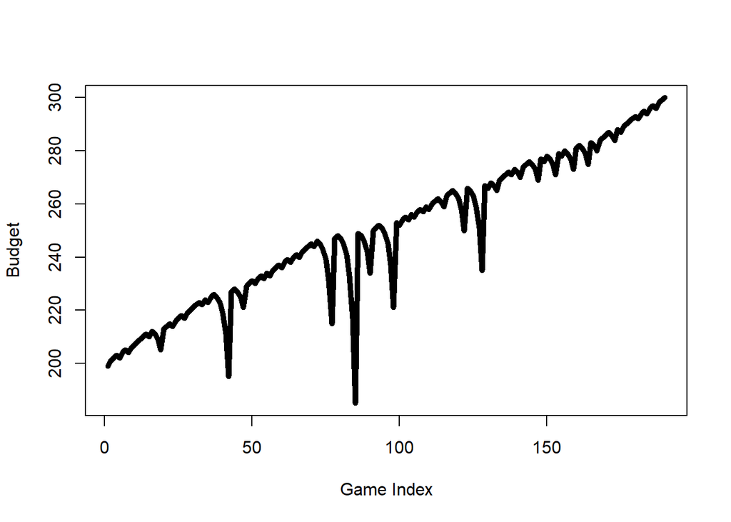

```r
set.seed(2)
gambler_1 <- one_series(1000,200,300,100)
plot(x = gambler_1$game_index, y = gambler_1$ending_budget, type = "l", lwd = 5, xlab = "Game Index", ylab = "Budget")
```

The gambler_1 above is a profitable example.

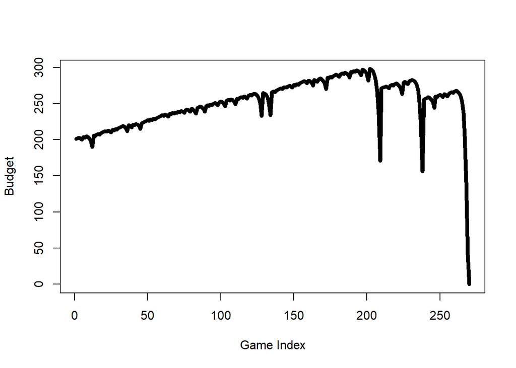

```r
set.seed(4)
gambler_2 <- one_series(1000,200,300,100)
plot(x = gambler_2$game_index, y = gambler_2$ending_budget, type = "l", lwd = 5, xlab = "Game Index", ylab = "Budget")
```

# 3 Impact of parameters on average earnings

Now, we’re going to change the value of the parameters and check if they have an impact on the average earnings.

## 3.1 max_games

In the code below, we set the max games from 600 to 1500 with a 100 interval. With each “max_games” value, we replicate the process for 5000 times and get the average earnings using the “earnings” function we define at section 2.3.

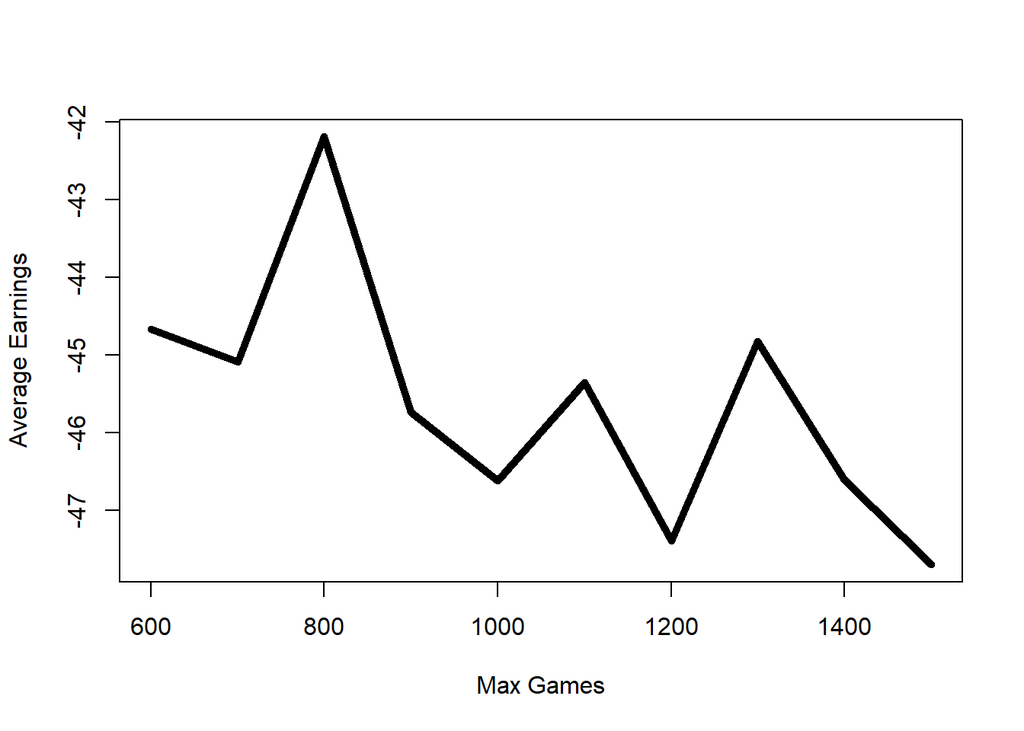

```r
set.seed(5)
average_earnings1 <- c()
for (i in 1:10) {
  average_earnings1[i] <- mean(replicate(5000,earnings(500+i*100,200,300,100)))-200
}
plot(x = seq(600, 1500, 100), y = average_earnings1, type = "l", lwd = 5, xlab = "Max Games", ylab = "Average Earnings")
```

Through the figure we can find out that the “max_games” parameter may have no impact on the average earnings, because the line fluctuates without an obvious tendency.

## 3.2 starting_budget

In the code below, we set the starting budget from 200 to 400 with a 10 interval. With each “starting_budget” value, we replicate the process for 5000 times and get the average earnings using the “earnings” function we define at section 2.3.

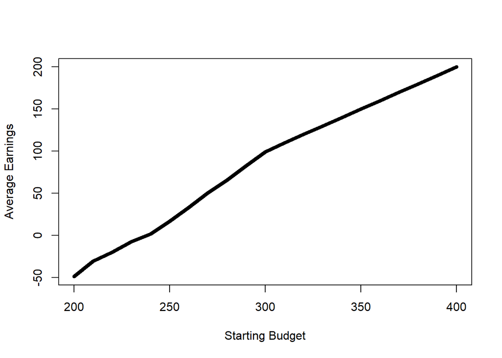

```r
set.seed(6)
average_earnings2 <- c()
for (i in 1:21) {
  average_earnings2[i] <- mean(replicate(5000,earnings(1000,190+i*10,300,100)))-200
}
plot(x = seq(200, 400, 10), y = average_earnings2, type = "l", lwd = 5, xlab = "Starting Budget", ylab = "Average Earnings")
```

Through the figure we can find out that the “starting_budget” parameter has a positive correlation to the average earnings, because the average earnings nearly show the same trend as the starting budget.

## 3.3 winning_threshold

In the code below, we set the winning threshold from 300 to 500 with a 20 interval. With each “winning_threshold” value, we replicate the process for 5000 times and get the average earnings using the “earnings” function we define at section 2.3.

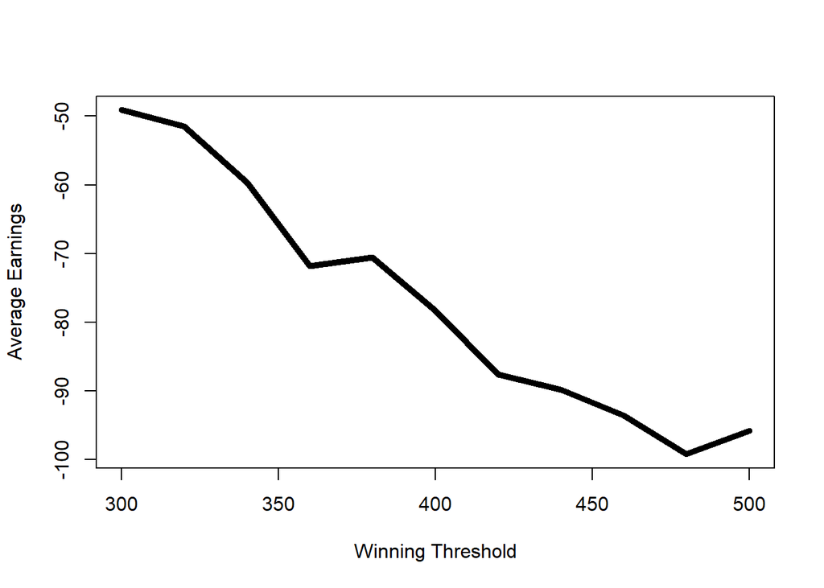

```r
set.seed(7)
average_earnings3 <- c()
for (i in 1:11) {
  average_earnings3[i] <- mean(replicate(5000,earnings(1000,200,280+20*i,100)))-200
}
plot(x = seq(300, 500, 20), y = average_earnings3, type = "l", lwd = 5, xlab = "Winning Threshold", ylab = "Average Earnings")
```

Through the figure we can find out that the “winning_threshold” parameter has a negative correlation to the average earnings, because the average earnings show the inverse trend as the winning threshold.

## 3.4 max_wager

In the code below, we set the max wager from 50 to 150 with a 10 interval. With each “max_wager” value, we replicate the process for 5000 times and get the average earnings using the “earnings” function we define at section 2.3.

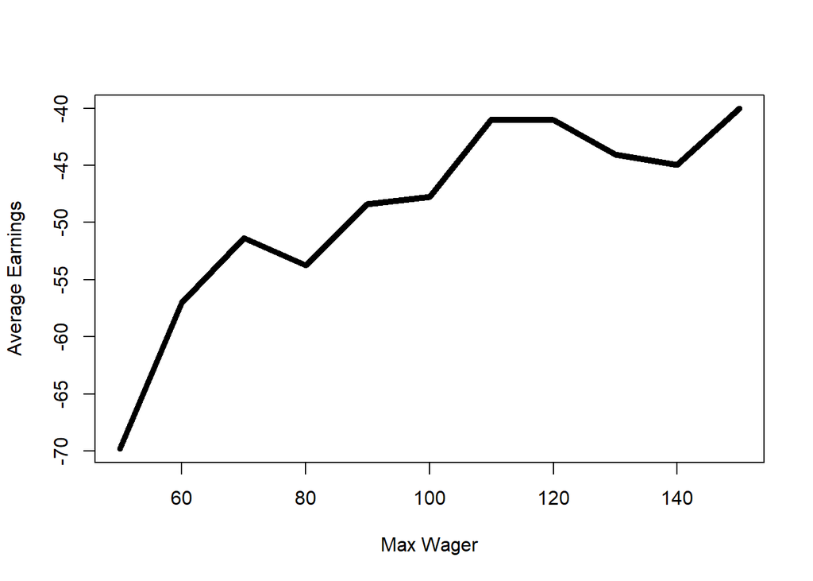

```r
set.seed(8)
average_earnings4 <- c()
for (i in 1:11) {
  average_earnings4[i] <- mean(replicate(5000,earnings(1000,200,300,40+10*i)))-200
}
plot(x = seq(50, 150, 10), y = average_earnings4, type = "l", lwd = 5, xlab = "Max Wager", ylab = "Average Earnings")
```

# 4 Average number of plays

In this section we will calculate the average number of plays before the gambler stopping.

```r
set.seed(9)
roulette_time <- function(max_games, starting_budget, winning_threshold, max_wager) {
  b <- one_series(max_games, starting_budget, winning_threshold, max_wager)
  return(b[length(b[,1]),1])
}
average_time = mean(replicate(1000,roulette_time(1000,200,300,100)))
average_time
```

```
## [1] 199.811
```

The average number of plays before the gambler stopping is around 199.811.

# 5 Limitations and uncertainty

1.Because of the limited storage and running speed of personal laptop, we can’t simulate the process for a large amount of times, which means that the results we got may be not a very good approximation of the real value. 2.We made some simplifications and didn’t use as much value of the parameters as possible to compare the difference.